# Salem’s Global Sailors: Visualization Essay

a guidone

3/27/2017

## Introduction: Salem Sailors: 1797-1832

This is an exploration data on sailors departing Salem, Massachusetts from 1797-1832. The data includes 3,307 voyages with 15,364 sailors with complete records. It should be noted that the 15,364 number does not mean that there were 15,364 individuals who were sailors on voyages as duplicates were not removed. This is important to remember but does not detract from the value of this data. For the purposes of this research, whether or not a cook described as ‘yellow/olive’ was a different person, or the same individual, on 3 different voyages matters less than the fact that there was a ‘yellow/olive’ cook on three different voyages departing Salem from 1797-1832.

A law passed in 1803 required crew lists to be kept which asked specific questions about each sailor including their birthplace, complexion, and position. It is important to remember that this did not ask for a sailor’s “race” but rather their “complexion.” Entries for “fair” and “ruddy” were common rather than simply “white.” The word “negro” was used at times for black people. Thus, records after 1803 are extremely thorough whereas the 1790s are not included in this dataset (except a few entered for 1797). I have removed all entries which do not meet all criteria examined. If I am looking at sailors’ birthplaces and positions, an entry which recorded a sailor’s birthplace but not his position is discarded.

Common understandings of early American shipping include the presence of African-Americans and black people onboard ships. The hustle and bustle of a sea port combined with ready access to free states or countries often allowed enslaved black people to reach freedom, such as Frederick Douglass who escaped from Baltimore. The data from Salem supports this understanding.

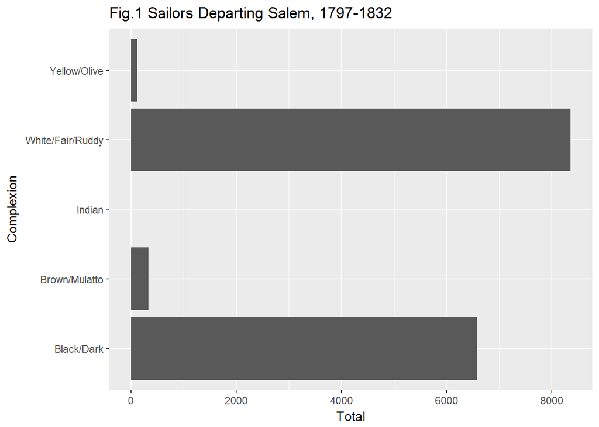

Less recognized is the presence of a group of in-between sailors who did not fit into simple black/white categorizations. Not black or dark, but also not white or fair skinned, these sailors were described as “Yellow,” “Olive,” “Swarthy”, “Indian,” “Brown,” and “Mulatto.” As can be seen above, these individuals were a minority on Salem ships but still warrant closer study for the unique diversity they represented. We will call these “global sailors” and they revealed that Salem’s position as a fulcrum of world trade created more than black/white diversity at the wharf and on ship. We can begin to get a deeper understanding of our global sailors by examining what positions they held at sea.

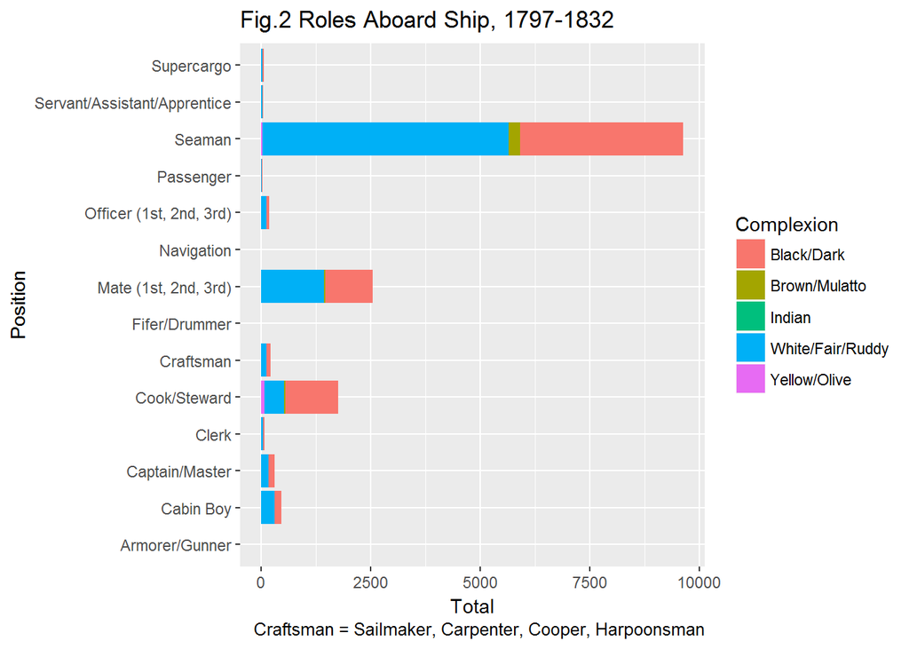

Most Global Sailors did not rise very high on the ship hierarchy. One of the most popular occupations for Global Sailors was as a cook.

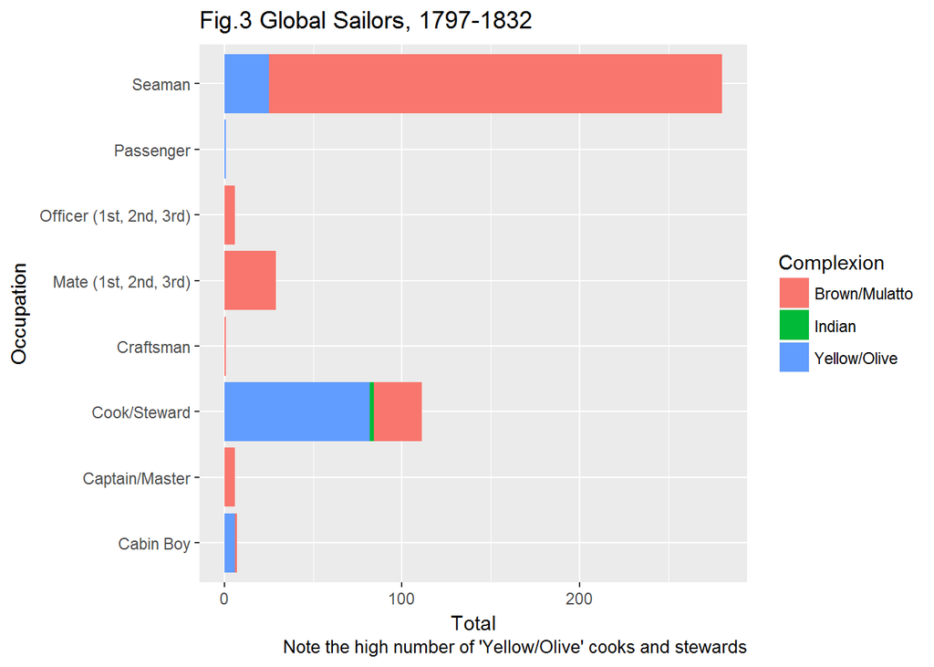

Proportionately Global Sailors were a minority of cooks and stewards, but other than seaman this was the most popular occupation they achieved.

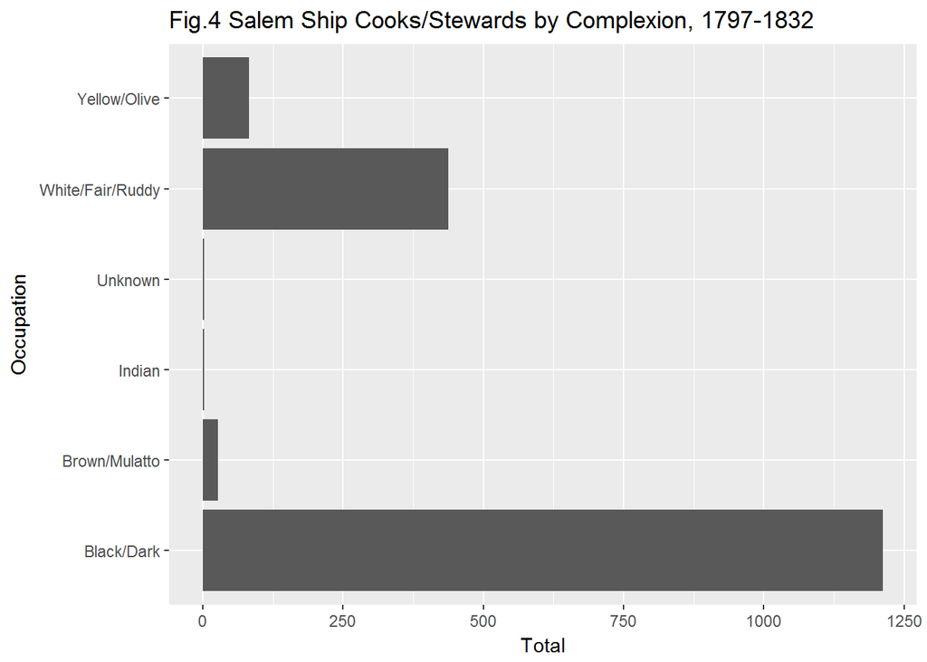

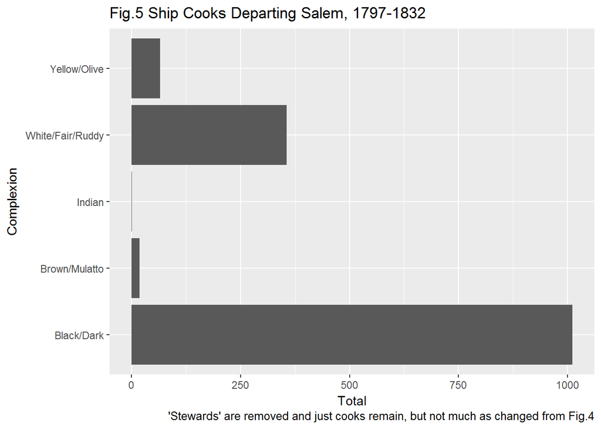

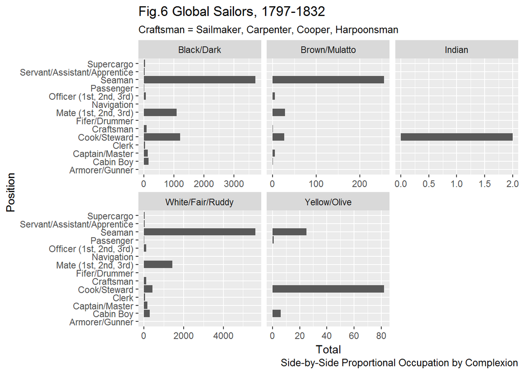

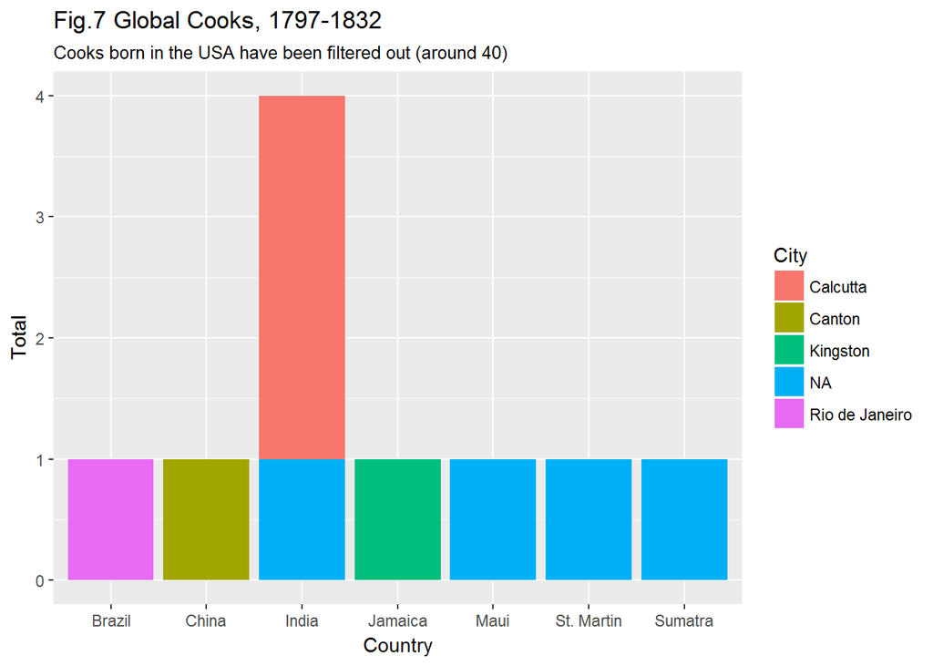

Here one can get a sense of these individuals’ birthplaces.

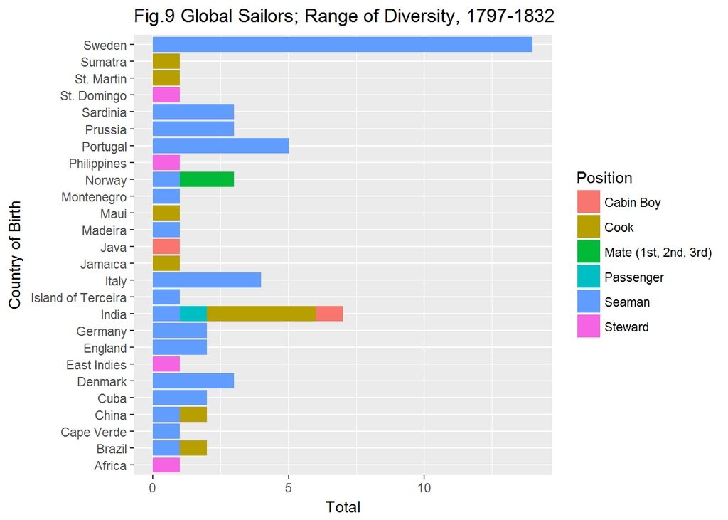

We can also discover what foreign cities were represented aboard Salem ships.

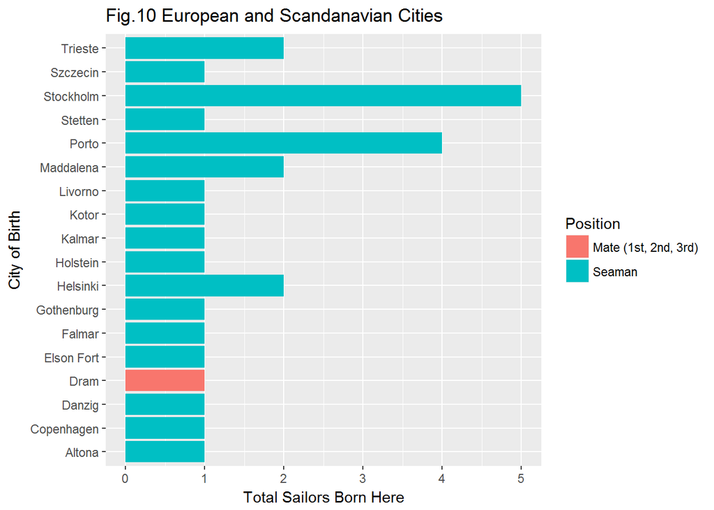

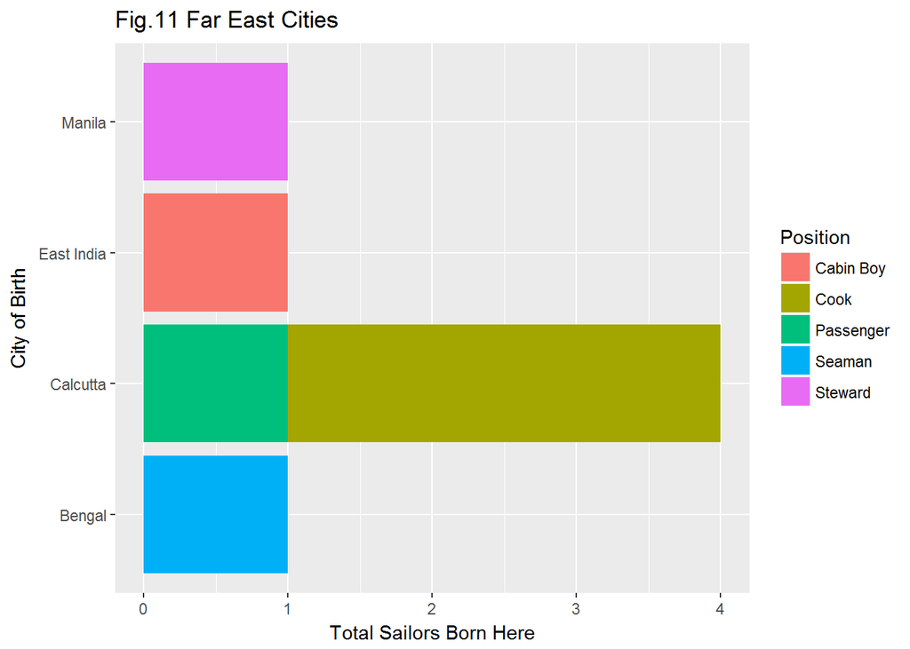

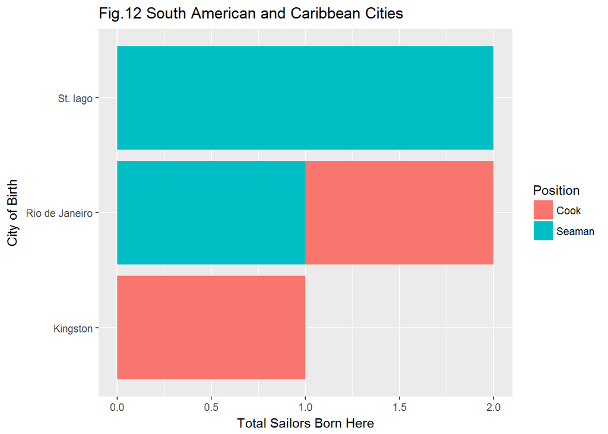

It is evident that sailors departing Salem included a range of individuals from around the world. This presents a more complicated and diverse picture of the traditional small-town New England sailor.